# 2016 Presidential Campaign - FEC Database Individual Contribution Analysis

### Data Description

This data comes from the Federal Election Commissions Contributor data from all states, found here: http://fec.gov/disclosurep/PDownload.do

The data only includes contributions from individuals counted by the FEC and does not include receipts from other sources. The data also only reflects the early part of the race, with no data included past 9/30/2015.

### Descriptive Univariate Graphs

The first barchart shows the amount raised by each candiate. Hillary has raised far more money as counted by this dataset. She is dominating rest of the field with over $60,000,000 raised. The next closest is Jeb Bush with over $20 Milllion raised.

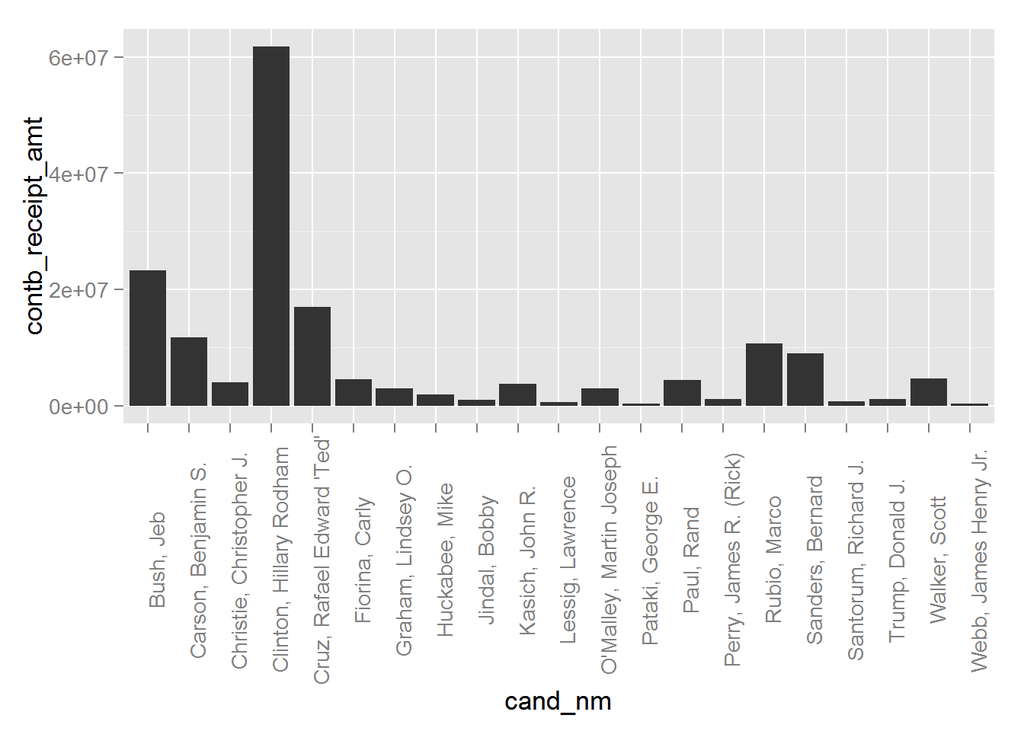

```
## [1] "Min.   :  365091  " "1st Qu.: 1013918  " "Median : 3734242  "
## [4] "Mean   : 7990391  " "3rd Qu.: 9018526  " "Max.   :61726374  "
```

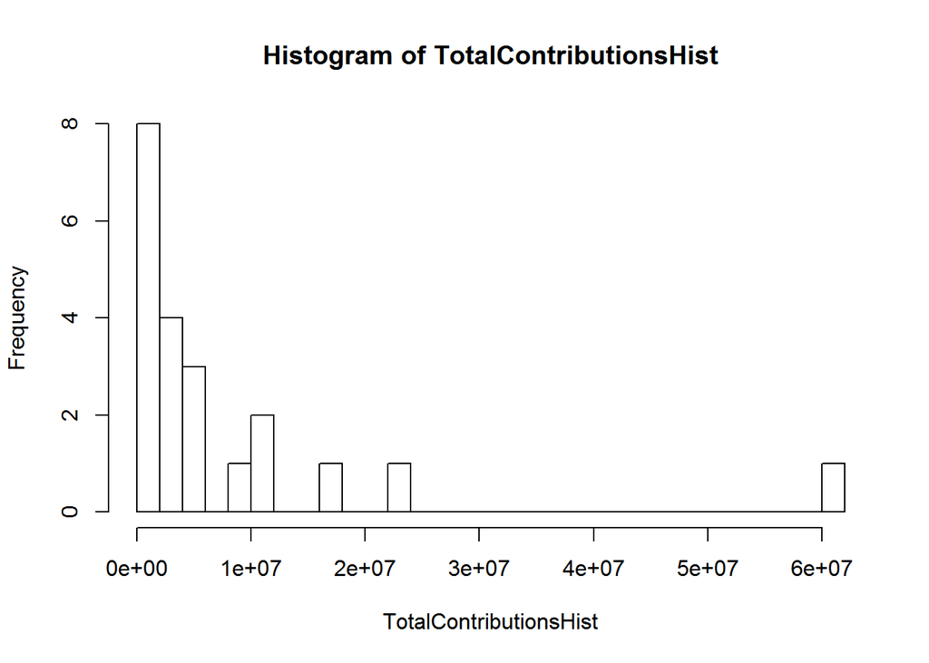

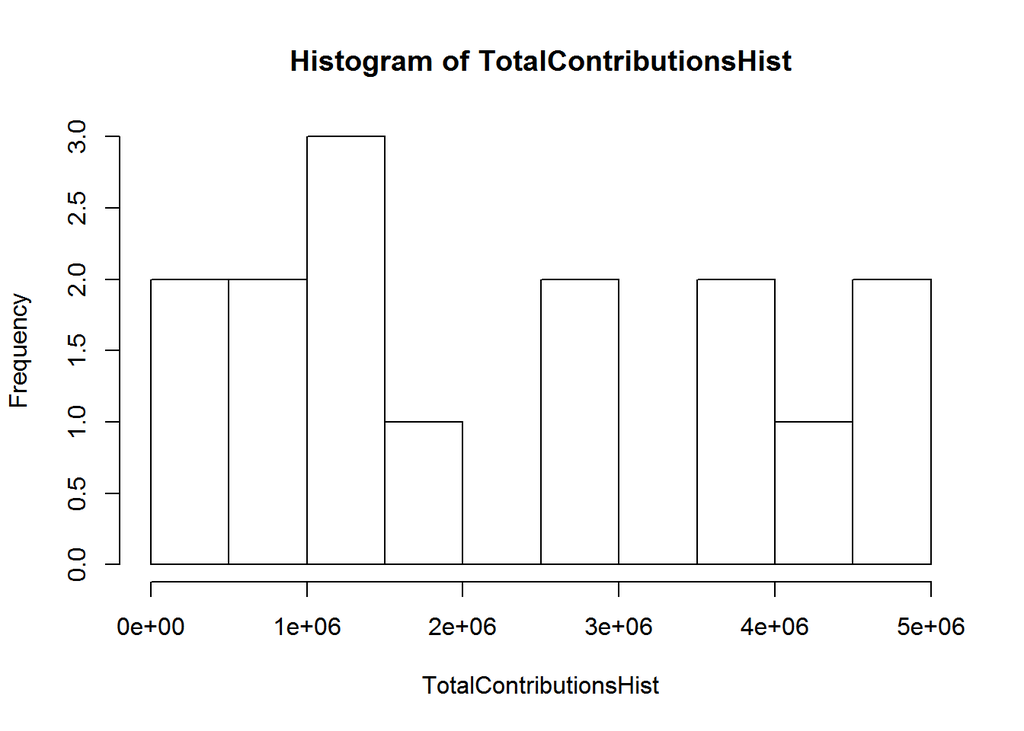

This bar chart shows the amount raised per state. Unsurprisingly California has the largest amount of total donations as California has the largest total population. California is followed by Texas then New york.

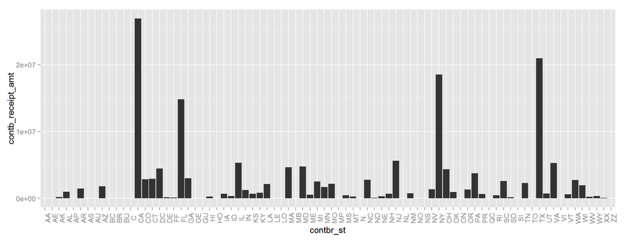

### Cumulative Sum over Time Graphs

I decided to look into the cumulative sum of the candidates contributions to see if I could find anything interesting. My first graph looks at Hilary alone. Hilary shows steady increase in funds, there are no huge leaps or flat areas which are immediately obvious.

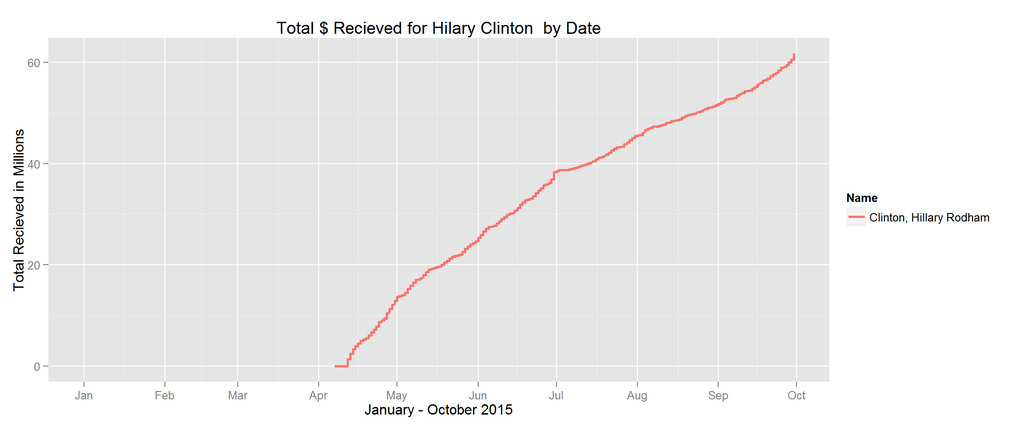

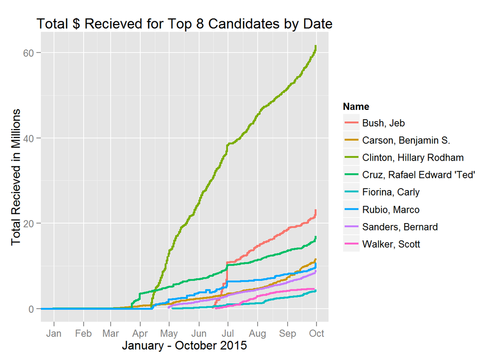

### Retired Contributions Analysis Graphs

This graph shows retired contribtions per candidate. Hilary is again in the lead. However, it is important to note that she also has the highest total contribution amount, so she might not have the highest proportion of retired contriubtions.

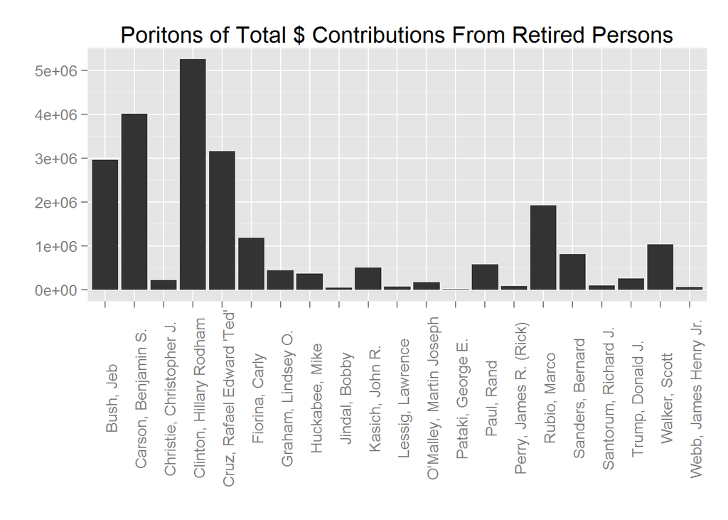

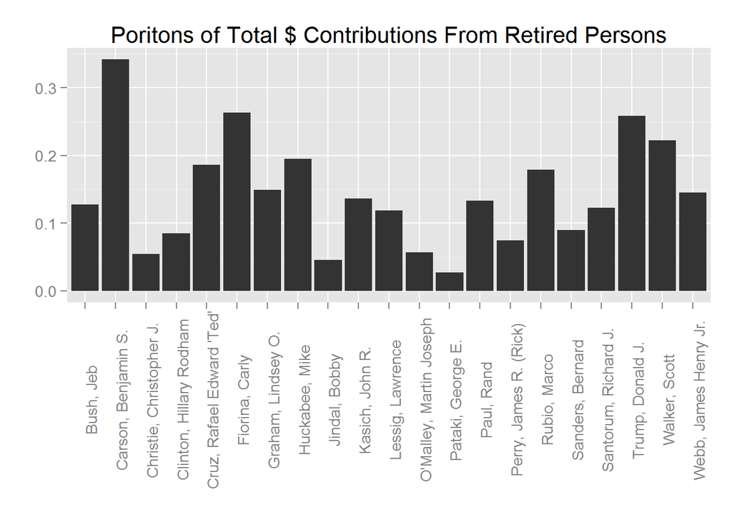

I want to test whether there is a relationship between the percent of income from retired persons and Total_contriubtions. To do this I make a scatter plot with Total contriubtions and a regression line.

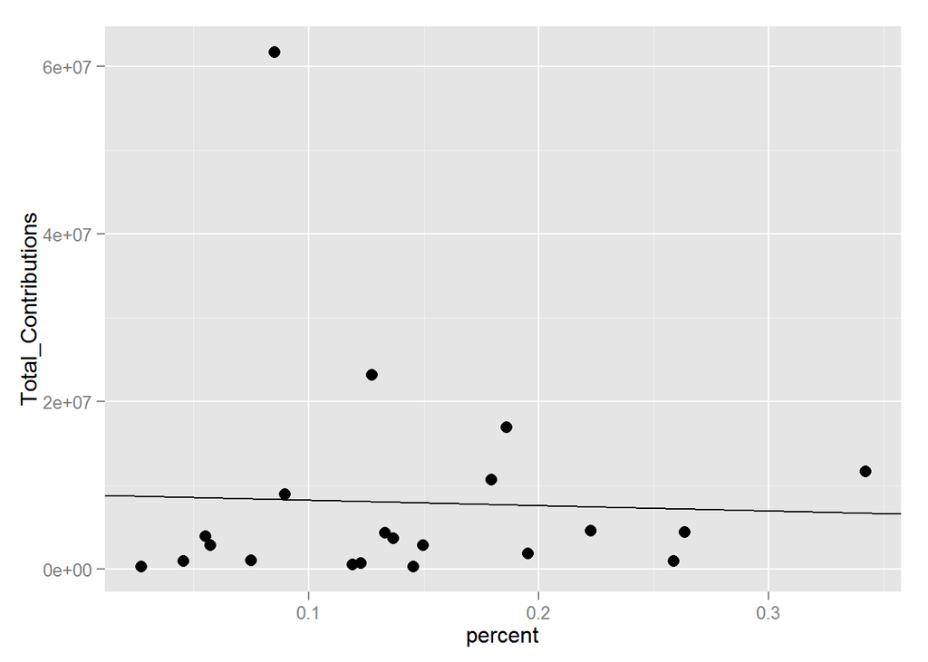

Here is the Summary of the correlation. As we can see the rSquared value is .001371477 which is very weak.

```
##
## Call:
## lm(formula = Total_Contributions ~ percent, data = df2)
##
## Residuals:
##      Min       1Q   Median       3Q      Max
## -8357454 -7302874 -4571427   689139 53368767
##
## Coefficients:
##             Estimate Std. Error t value Pr(>|t|)
## (Intercept)  8893144    6373178   1.395    0.179
## percent     -6291339   38947000  -0.162    0.873
##
## Residual standard error: 14040000 on 19 degrees of freedom
## Multiple R-squared:  0.001371,   Adjusted R-squared:  -0.05119
## F-statistic: 0.02609 on 1 and 19 DF,  p-value: 0.8734
```

Hilary dominates the total, so lets try this again with Hilary removed.

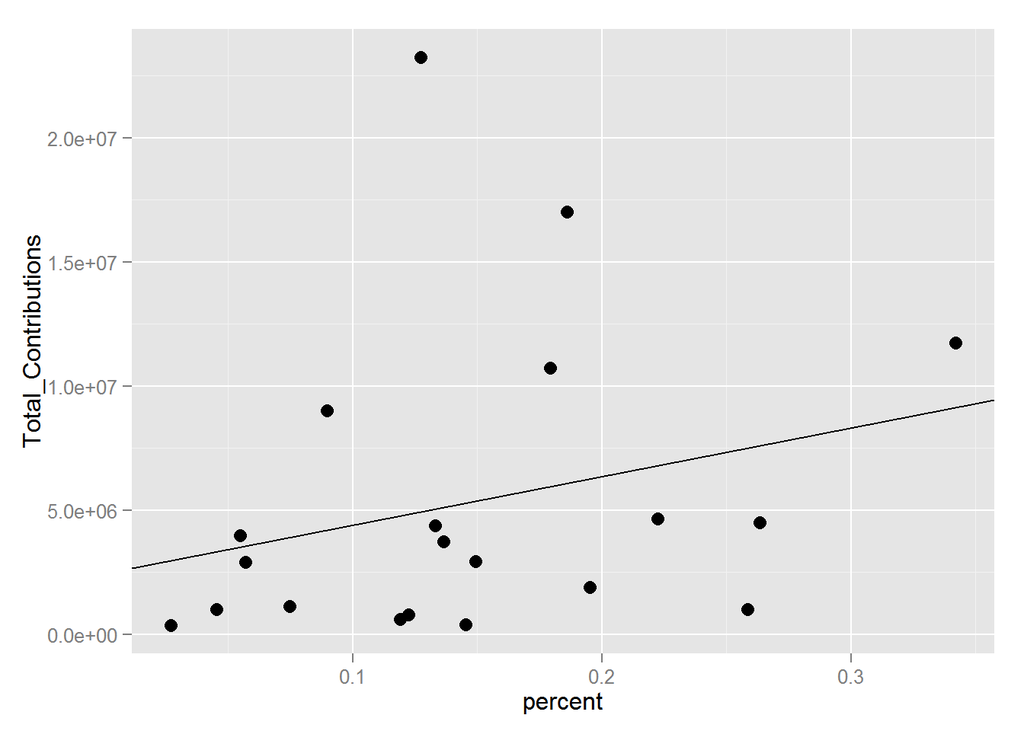

```
##
## Call:
## lm(formula = Total_Contributions ~ percent, data = noHilSub)
##
## Residuals:
##      Min       1Q   Median       3Q      Max
## -6491727 -3329642 -2223127  1002978 18313994
##
## Coefficients:
##             Estimate Std. Error t value Pr(>|t|)
## (Intercept)  2434829    2858191   0.852    0.405
## percent     19594068   17156584   1.142    0.268
##
## Residual standard error: 6099000 on 18 degrees of freedom
## Multiple R-squared:  0.06757,    Adjusted R-squared:  0.01576
## F-statistic: 1.304 on 1 and 18 DF,  p-value: 0.2684
```

### Location Correlation Analysis

First I want to study Washington D.C’s funding correlation with overall funding. Like the retired plot I made a bar graph showing the percent of contribution total which comes from Washington D.C

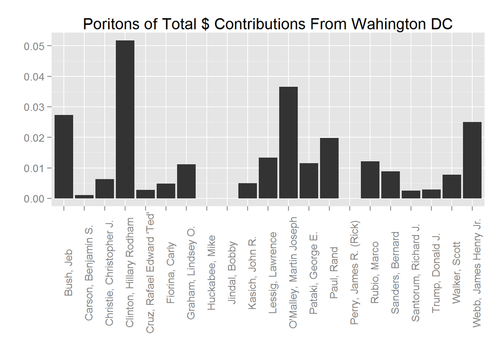

I created a graph that looks at the percent of contributions from DC with the total donations overall

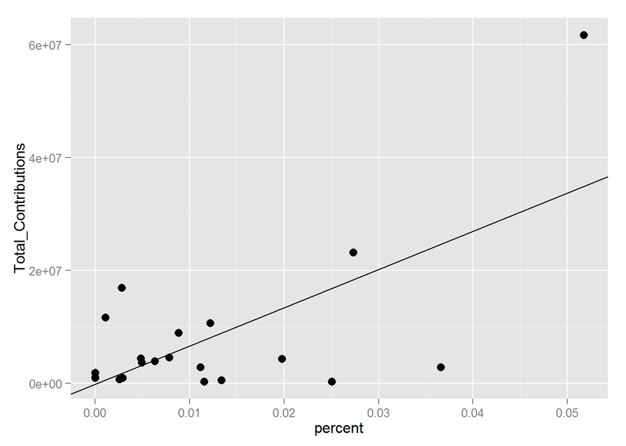

There looks to be a stronger correlation with percent of contriubtions from Washignton DC then with retired persons, with every extra .01 % from Washington DC leading to an expected increase of around $7M in total contributions. The R Squared here is not too high, but is not weak enough to be dicounted completely:

```
## [1] 0.4421663
```

Now I will try to see DC’s correlation compared with States and Cities. First, here is a scatter plot showing what percent of each candidates money comes from every state. For instance, 60% of Chris Christie’s money comes from his native New Jersey, as indicated by the larger dot. I limited the data to state values which make over 1.5% of the value for that candidate to help filter out the less relevant variables.

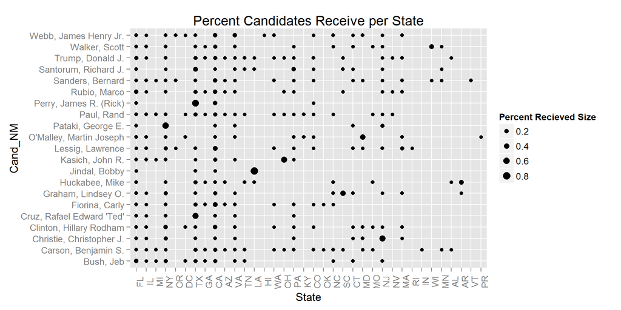

Here we can see that the DC area funding correlates more with overall candidate funding then any other State/Region which would make sense as it is the center of politics in the United States I limited the values shown to RSquared values over .05.

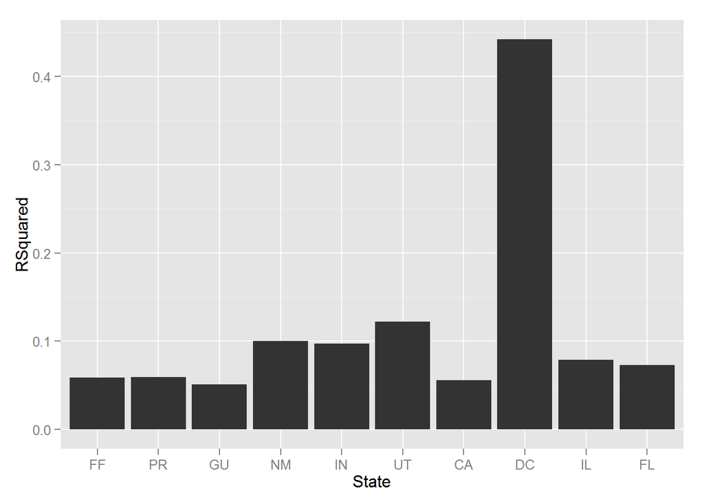

However, DC is a city as well as a district, so influence is more concentrated then with States.Below is a graph showing which Cities give to which candidates. For simplicity and processing, I limited the cities to the top 75 cities by number of donations. Also, as I did with the states, I limited the threshold of the data to cities which are over 1.5% of any candidates total contributions.

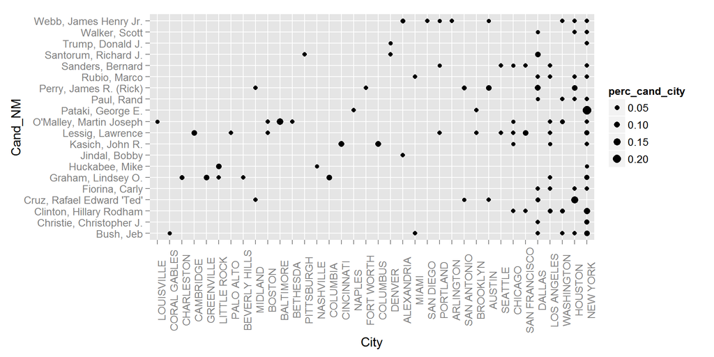

Here is a graph of the RSquared data for each city. Washington DC still shows the highest R Squared value. Surprisingly to me, Mineapolis is the second highest.

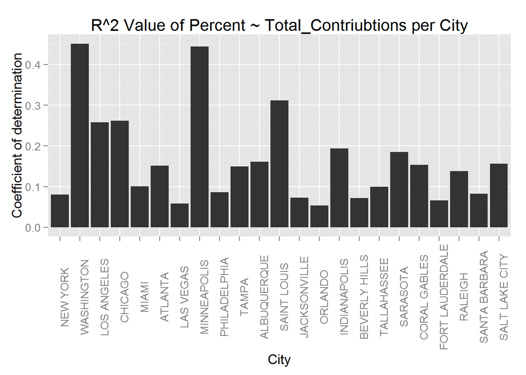

I want to further narrow down which areas correlate the most with overall funding, so I will now repeat the process but with Zip Codes. Here is a scatter plot. I made the cut to be counted as .5% rather then 1.5% because Zip Codes are smaller and naturally will make a smaller part of the Total Contributions. For some context 10024 is the Zip Code for the upper West Side in Manhattan. 77024 is a Zip Code in Houston, two miles away from where Ted Cruz went to High School.

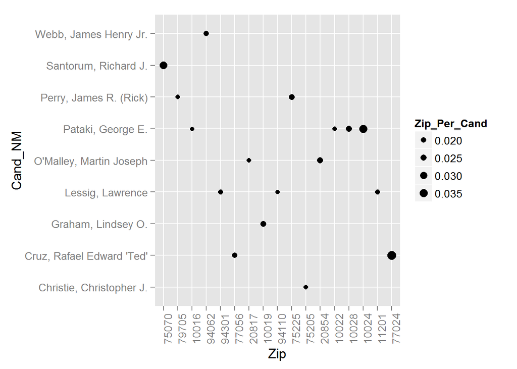

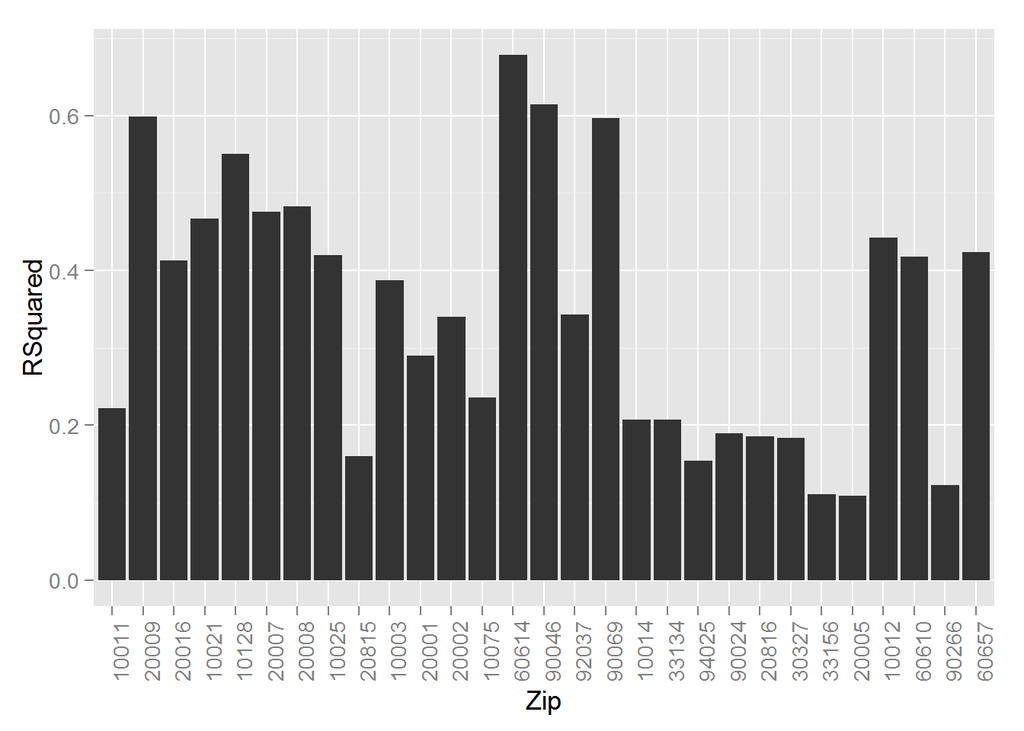

These places are all very wealthy, liberal and often culturally important areas. This would make sense as wealthy Democrats are more likely to live in large cities, and have their wealth concentrated into a few Zip Codes. Republican wealth is more likely to be spread over several Zip Codes. As a result we would expect to find that the Democrats who capture these key areas are likely to have a larger overall base of financial support.

These next two graphs show the total value of the contributions from 60614, then the portion of the candidates total that are from 60614.

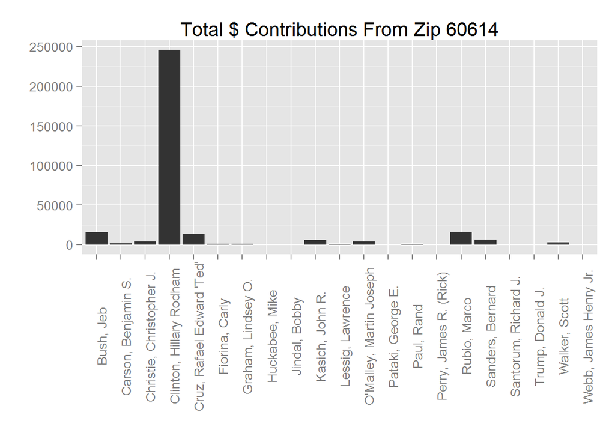

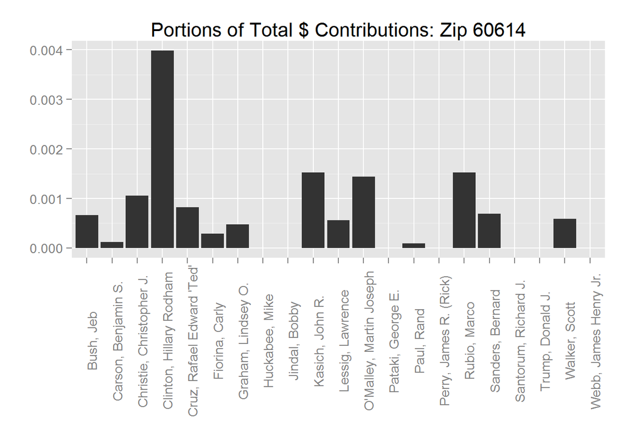

Here is the a scatter plot with trendlines for Zip Code 60614

```
##
## Call:
## lm(formula = Total_Contributions ~ percent, data = ChiZipDF2)
##
## Residuals:
##       Min        1Q    Median        3Q       Max
## -14821103  -2853683    806958   1921106  15230034
##
## Coefficients:
##               Estimate Std. Error t value Pr(>|t|)
## (Intercept) -2.556e+04  2.152e+06  -0.012    0.991
## percent      1.217e+10  1.925e+09   6.325 4.53e-06 ***
## ---
## Signif. codes:  0 '***' 0.001 '**' 0.01 '*' 0.05 '.' 0.1 ' ' 1
##
## Residual standard error: 7972000 on 19 degrees of freedom
## Multiple R-squared:  0.678,  Adjusted R-squared:  0.6611
## F-statistic: 40.01 on 1 and 19 DF,  p-value: 4.534e-06
```

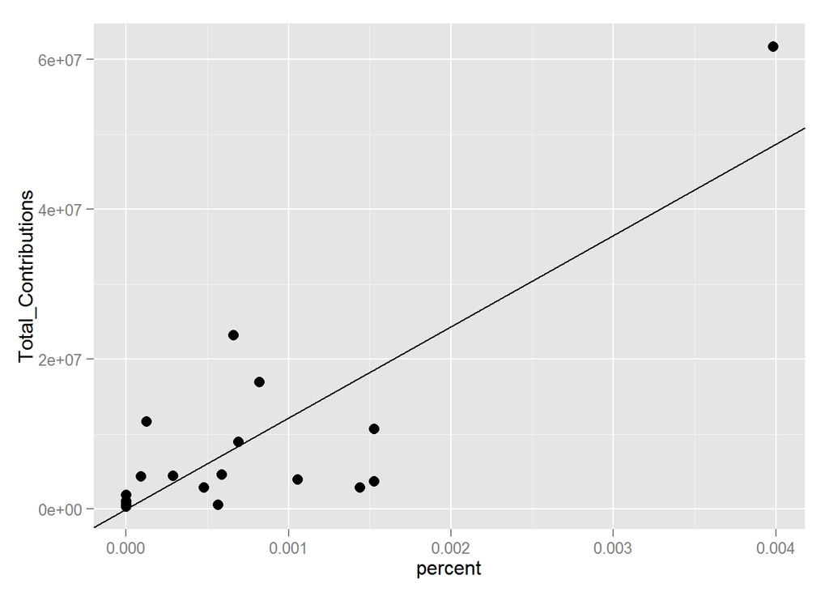

Here is the same graph but without Hilary, as well as a correlation summary.

```
##
## Call:
## lm(formula = Total_Contributions ~ percent, data = noHilSub2)
##
## Residuals:
##      Min       1Q   Median       3Q      Max
## -6015844 -3019551 -2301537   827693 17293790
##
## Coefficients:
##              Estimate Std. Error t value Pr(>|t|)
## (Intercept) 3.410e+06  1.817e+06   1.876   0.0769 .
## percent     3.846e+09  2.518e+09   1.527   0.1440
## ---
## Signif. codes:  0 '***' 0.001 '**' 0.01 '*' 0.05 '.' 0.1 ' ' 1
##
## Residual standard error: 5942000 on 18 degrees of freedom
## Multiple R-squared:  0.1147, Adjusted R-squared:  0.06556
## F-statistic: 2.333 on 1 and 18 DF,  p-value: 0.144
```

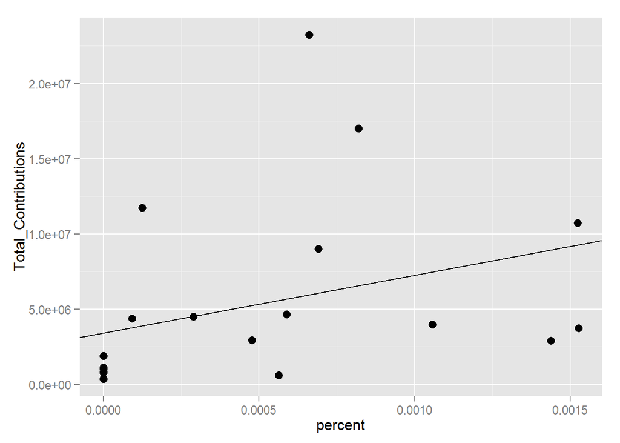

Without Clinton, the correlation is much less strong. It would be interesting to compare this to the data in the 2004 and 2008 election and before to see if these Zip Codes correlate with mainstream well funded Democrats(essentially only Hilary in this election) or if they are simply very pro Hilary and would not have a strong correlation in elections not involving Hilary.

# Final Plots and Summary

### Plot One:

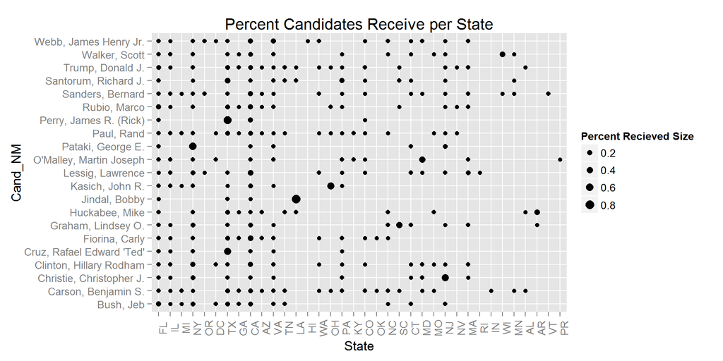

### Plot Two:

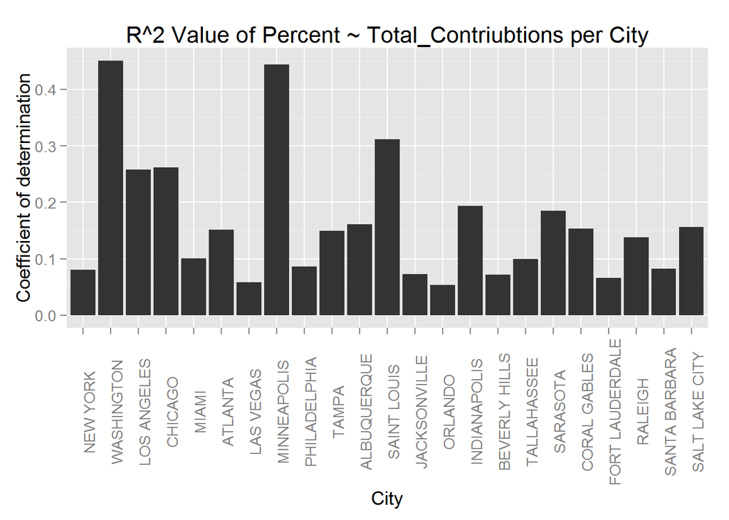

#### Description Two:

This graph shows the “Coefficient of determination” or R Squared Score betweeen contributions for a candidate which come from that particular city, and the Total_contriubitons overall. In other words this score shows the proportion of the differences in the Total Contributions for each candidate, which can be predicted by the percentage of Total Contriubtions each candidate gets from the respective city.

Washington DC unsurprisingly has the highest Rsquared value, which makes sense given the fact that DC is the seat of American politics. Minneapolis is second for less clear reasons. Surprisingly New York barely makes the .05 threshold for appearing on the graph. The inclusion of Salt Lake City at a .16 value is logical as it is the center for the Mormon Faith, and would most likely be a good indicator of the contribtions of the entire Mormon community.

### Plot Three:

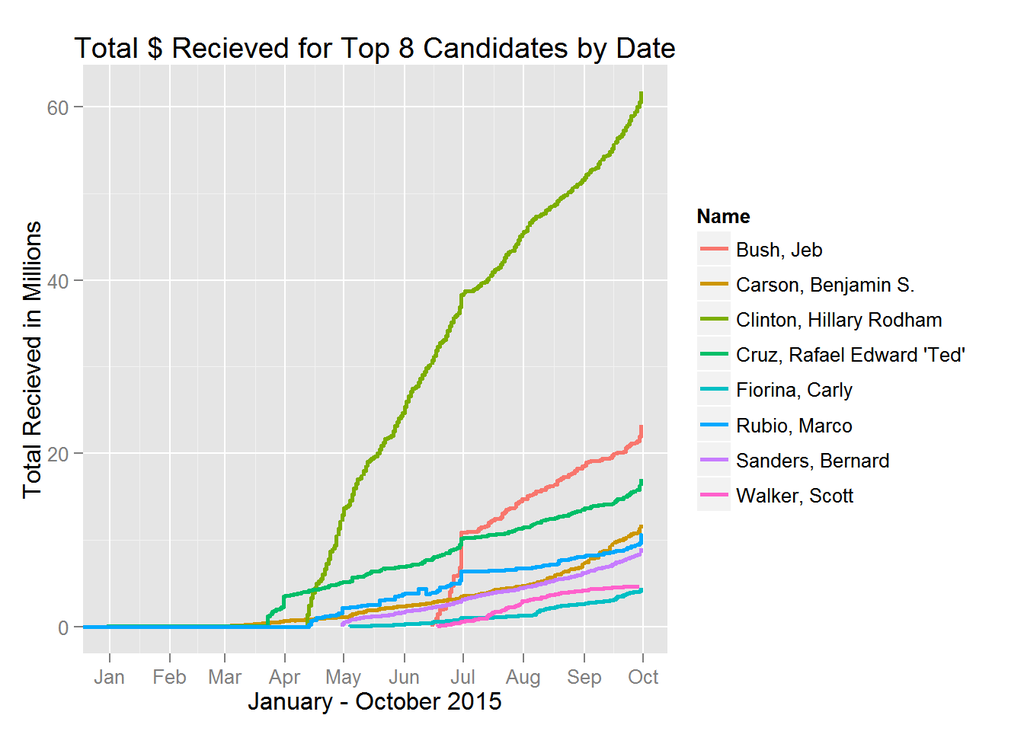

#### Description Three:

This graph shows the top 8 eight candidates by there campaign contributions over time. The jump on July 1 was due to the end of the campaign rebate program,which showed up in my data as negative total contriubitons. This had been depressing the overall campaign contributions of many of the canidates significantly. Most notably was Jeb Bush who saw a jump of around $4 Million Dollars as a result of the rebate program’s end.

### Reflections:

The data provided many intriguing insights on the election and election funding. The first is that Hilary is dominating in the democratic polls for a reason. She has taken far more money in then any other candidate, and that should really help her hold off Bernie Sanders and help tremendously with the genereal election as well.

It was also interesting that the candidates with the highest level of retired support were the three outisiders on the republican side, Carly Fiorina, Donald Trump and Ben Carson. This could possibly indicate that retired persons are likely very disastisfied with the Republican establishment, as these three candidates are not establishment republicans and are classified as outsiders.

In the future I would like to compare the correlation of the funding totals of different locations on Republicans and Democrats sepearte total funding numbers. I would also like to look at which jobs are the most influential, and map rSquared values as I did with location. I would also like to map the infulence of these locations and jobs on actuall poll numbers and votes, not just overall contriubtions.

It is important to note that these amounts only cover the money going to the candidates themselves. The candidates also have Superpacs which they are not officially allowed to control. These Superpacs are allowed to take unlimited amount of campaign contributions and as a result often have even more money then the individual campaigns.